# Предобработка данных и функции потерь в линейной регрессии

## Данные

Для демонстраций загрузим набор данных [Automobile Data Set](https://archive.ics.uci.edu/ml/datasets/Automobile). В данных присутствуют категориальные, целочисленные и вещественнозначные признаки.

```python
import pandas as pd
X_raw = pd.read_csv("https://archive.ics.uci.edu/ml/machine-learning-databases/autos/imports-85.data", \
                    header=None, na_values=["?"])
```

```python
X_raw.head()
```

|  | 0 | 1 | 2 | 3 | 4 | 5 | 6 | 7 | 8 | 9 | ... | 16 | 17 | 18 | 19 | 20 | 21 | 22 | 23 | 24 | 25 |
| --- | --- | --- | --- | --- | --- | --- | --- | --- | --- | --- | --- | --- | --- | --- | --- | --- | --- | --- | --- | --- | --- |
| 0 | 3 | NaN | alfa-romero | gas | std | two | convertible | rwd | front | 88.6 | ... | 130 | mpfi | 3.47 | 2.68 | 9.0 | 111.0 | 5000.0 | 21 | 27 | 13495.0 |
| 1 | 3 | NaN | alfa-romero | gas | std | two | convertible | rwd | front | 88.6 | ... | 130 | mpfi | 3.47 | 2.68 | 9.0 | 111.0 | 5000.0 | 21 | 27 | 16500.0 |
| 2 | 1 | NaN | alfa-romero | gas | std | two | hatchback | rwd | front | 94.5 | ... | 152 | mpfi | 2.68 | 3.47 | 9.0 | 154.0 | 5000.0 | 19 | 26 | 16500.0 |
| 3 | 2 | 164.0 | audi | gas | std | four | sedan | fwd | front | 99.8 | ... | 109 | mpfi | 3.19 | 3.40 | 10.0 | 102.0 | 5500.0 | 24 | 30 | 13950.0 |
| 4 | 2 | 164.0 | audi | gas | std | four | sedan | 4wd | front | 99.4 | ... | 136 | mpfi | 3.19 | 3.40 | 8.0 | 115.0 | 5500.0 | 18 | 22 | 17450.0 |

5 rows × 26 columns

```python
y = X_raw[25]
X_raw = X_raw.drop(25, axis=1)
```

### Заполнение пропусков

В матрице объекты-признаки могут быть пропущенные значения, и это вызовет ошибку при попытке передать такую матрицу в функцию обучения модели или даже предобработки. Если пропусков немного, можно удалить объекты с пропусками из обучающей выборки. Заполнить пропуски можно разными способами:

- заполнить средними (mean, median);
- предсказывать пропущенные значения по непропущенным.

Часто используют первый вариант - он проще. Для заполнения константами можно использовать метод датафрейма `fillna`, для замены средними - класс `impute.SimpleImputer` (в более старых версиях `scikit-learn` - `preprocessing.Imputer`).

```python
X_raw.isnull().any().any()
```

```
True
```

```python
X_raw.isnull().sum()
```

```
0      0
1     41
2      0
3      0
4      0
5      2
6      0
7      0
8      0
9      0
10     0
11     0
12     0
13     0
14     0
15     0
16     0
17     0
18     4
19     4
20     0
21     2
22     2
23     0
24     0
dtype: int64
```

```python
from sklearn.impute import SimpleImputer
```

```python
# для удобства работы с нашим датасетом создаем маску, указывающую на столбцы с категориальными признаками
cat_features_mask = (X_raw.dtypes == "object").values # категориальные признаки имеют тип "object"
```

```python
# для вещественнозначных признаков заполним пропуски средними
X_real = X_raw[X_raw.columns[~cat_features_mask]]
mis_replacer = SimpleImputer(strategy="mean")
X_no_mis_real = pd.DataFrame(data=mis_replacer.fit_transform(X_real), columns=X_real.columns)
# для категориальных - пустыми строками
X_cat = X_raw[X_raw.columns[cat_features_mask]].fillna("")
X_no_mis = pd.concat([X_no_mis_real, X_cat], axis=1)
```

```python
X_no_mis.head()
```

|  | 0 | 1 | 9 | 10 | 11 | 12 | 13 | 16 | 18 | 19 | ... | 2 | 3 | 4 | 5 | 6 | 7 | 8 | 14 | 15 | 17 |
| --- | --- | --- | --- | --- | --- | --- | --- | --- | --- | --- | --- | --- | --- | --- | --- | --- | --- | --- | --- | --- | --- |
| 0 | 3.0 | 122.0 | 88.6 | 168.8 | 64.1 | 48.8 | 2548.0 | 130.0 | 3.47 | 2.68 | ... | alfa-romero | gas | std | two | convertible | rwd | front | dohc | four | mpfi |
| 1 | 3.0 | 122.0 | 88.6 | 168.8 | 64.1 | 48.8 | 2548.0 | 130.0 | 3.47 | 2.68 | ... | alfa-romero | gas | std | two | convertible | rwd | front | dohc | four | mpfi |
| 2 | 1.0 | 122.0 | 94.5 | 171.2 | 65.5 | 52.4 | 2823.0 | 152.0 | 2.68 | 3.47 | ... | alfa-romero | gas | std | two | hatchback | rwd | front | ohcv | six | mpfi |
| 3 | 2.0 | 164.0 | 99.8 | 176.6 | 66.2 | 54.3 | 2337.0 | 109.0 | 3.19 | 3.40 | ... | audi | gas | std | four | sedan | fwd | front | ohc | four | mpfi |
| 4 | 2.0 | 164.0 | 99.4 | 176.6 | 66.4 | 54.3 | 2824.0 | 136.0 | 3.19 | 3.40 | ... | audi | gas | std | four | sedan | 4wd | front | ohc | five | mpfi |

5 rows × 25 columns

```python
X_no_mis.isnull().any().any()
```

```
False
```

Всегда нужно осознавать, случайны ли пропуски в каком-то признаке. Иногда факт отсутствия информации о значении признака может сам быть важным признаком, который необходимо добавить к другим признакам.

**Пример:** предсказание возраста пользователя по данным с его телефона. Поскольку люди старшего возраста чаще пользуются простыми телефонами, факт отсутствия каких-то данных (например, истории посещенных интернет-страниц), скорее всего, будет хорошим признаком.

Для категориальных признаков рекомендуется создавать отдельную категорию, соответствующую пропущенному значению.

### Преобразование нечисловых признаков

Практически все методы машинного обучения требуют, чтобы на вход функции обучения подавалась вещественная матрица. В процессе обучения используются свойства вещественных чисел, в частности, возможность сравнения и применения арифметических операций. Поэтому, даже если формально в матрице объекты-признаки записаны числовые значения, нужно всегда анализировать, можно ли относиться к ним как к числам.

**Пример:** некоторые признаки могут задаваться целочисленными хешами или id (например, id пользователя соц. сети), однако нельзя сложить двух пользователей и получить третьего, исходя из их id (как это может сделать линейная модель).

К категориальным признакам, принимающим значения из неупорядоченного конечного множества $K$, обычно применяют [one-hot encoding](http://scikit-learn.org/stable/modules/preprocessing.html#encoding-categorical-features) (вместо одного признака создают $K$ бинарных признаков - по одному на каждое возможное значение исходного признака). В `sklearn` это можно сделать с помощью классов `LabelEncoder` + `OneHotEncoder`, но проще использовать функцию `pd.get_dummies`.

Следует заметить, что в новой матрице будет очень много нулевых значений. Чтобы не хранить их в памяти, можно задать параметр `OneHotEncoder(sparse=True)` или `pd.get_dummies(sparse=True)`, и метод вернет [разреженную матрицу](http://docs.scipy.org/doc/scipy/reference/sparse.html), в которой хранятся только ненулевые значения. Выполнение некоторых операций с такой матрицей может быть неэффективным, однако большинство методов sklearn умеют работать с разреженными матрицами.

**Вопрос:** стоит ли применять one-hot encoding для признаков с большим числом категорий (например, id)? Почему?

**Вопрос:** какая проблема возникнет при применении вышеописанного способа кодирования для обучения линейной регрессии?

Необходимо удалить один из столбцов, созданных для каждого признака. Для этого в get_dummies надо поставить drop_first=True.

```python
X_no_mis.shape
```

```
(205, 25)
```

```python
X_dum = pd.get_dummies(X_no_mis, drop_first=True)
print(X_dum.shape)
X_dum.head()
```

```
(205, 66)
```

|  | 0 | 1 | 9 | 10 | 11 | 12 | 13 | 16 | 18 | 19 | ... | 15_three | 15_twelve | 15_two | 17_2bbl | 17_4bbl | 17_idi | 17_mfi | 17_mpfi | 17_spdi | 17_spfi |
| --- | --- | --- | --- | --- | --- | --- | --- | --- | --- | --- | --- | --- | --- | --- | --- | --- | --- | --- | --- | --- | --- |
| 0 | 3.0 | 122.0 | 88.6 | 168.8 | 64.1 | 48.8 | 2548.0 | 130.0 | 3.47 | 2.68 | ... | 0 | 0 | 0 | 0 | 0 | 0 | 0 | 1 | 0 | 0 |
| 1 | 3.0 | 122.0 | 88.6 | 168.8 | 64.1 | 48.8 | 2548.0 | 130.0 | 3.47 | 2.68 | ... | 0 | 0 | 0 | 0 | 0 | 0 | 0 | 1 | 0 | 0 |
| 2 | 1.0 | 122.0 | 94.5 | 171.2 | 65.5 | 52.4 | 2823.0 | 152.0 | 2.68 | 3.47 | ... | 0 | 0 | 0 | 0 | 0 | 0 | 0 | 1 | 0 | 0 |
| 3 | 2.0 | 164.0 | 99.8 | 176.6 | 66.2 | 54.3 | 2337.0 | 109.0 | 3.19 | 3.40 | ... | 0 | 0 | 0 | 0 | 0 | 0 | 0 | 1 | 0 | 0 |
| 4 | 2.0 | 164.0 | 99.4 | 176.6 | 66.4 | 54.3 | 2824.0 | 136.0 | 3.19 | 3.40 | ... | 0 | 0 | 0 | 0 | 0 | 0 | 0 | 1 | 0 | 0 |

5 rows × 66 columns

Помимо категориальных, преобразования требуют, например, строковые признаки. Их можно превращать в матрицу частот слов CountVectorizer, матрицу частот буквосочетаний фиксированной длины, можно извлекать другие признаки (например, длина строки).

### Масштабирование признаков

При начале работы с данными всегда рекомендуется приводить все признаки к одному масштабу. Это важно по нескольким причинам:

- ускорение обучения модели;
- улучшение численной устойчивости при работе с матрицей объекты-признаки
- для линейных моделей: интерпретация весов при признаках как меры их значимости

(полезная ссылка: https://towardsdatascience.com/understand-data-normalization-in-machine-learning-8ff3062101f0)

Первый популярный способ масштабирования - нормализация: вычитание среднего из каждого признака и деление на стандартное отклонение (`StandardScaler` в `sklearn`). Второй популярный способ: вычитание минимума из каждого признака, а затем деление на разницу максимального и минимального значения (`MinMaxScaler` в `sklearn`).

```python
from sklearn.preprocessing import StandardScaler, MinMaxScaler
```

```python
normalizer = MinMaxScaler()
X_real_norm_np = normalizer.fit_transform(X_dum)
X = pd.DataFrame(data=X_real_norm_np)
```

```python
X.head()
```

|  | 0 | 1 | 2 | 3 | 4 | 5 | 6 | 7 | 8 | 9 | ... | 56 | 57 | 58 | 59 | 60 | 61 | 62 | 63 | 64 | 65 |
| --- | --- | --- | --- | --- | --- | --- | --- | --- | --- | --- | --- | --- | --- | --- | --- | --- | --- | --- | --- | --- | --- |
| 0 | 1.0 | 0.298429 | 0.058309 | 0.413433 | 0.316667 | 0.083333 | 0.411171 | 0.260377 | 0.664286 | 0.290476 | ... | 0.0 | 0.0 | 0.0 | 0.0 | 0.0 | 0.0 | 0.0 | 1.0 | 0.0 | 0.0 |
| 1 | 1.0 | 0.298429 | 0.058309 | 0.413433 | 0.316667 | 0.083333 | 0.411171 | 0.260377 | 0.664286 | 0.290476 | ... | 0.0 | 0.0 | 0.0 | 0.0 | 0.0 | 0.0 | 0.0 | 1.0 | 0.0 | 0.0 |
| 2 | 0.6 | 0.298429 | 0.230321 | 0.449254 | 0.433333 | 0.383333 | 0.517843 | 0.343396 | 0.100000 | 0.666667 | ... | 0.0 | 0.0 | 0.0 | 0.0 | 0.0 | 0.0 | 0.0 | 1.0 | 0.0 | 0.0 |
| 3 | 0.8 | 0.518325 | 0.384840 | 0.529851 | 0.491667 | 0.541667 | 0.329325 | 0.181132 | 0.464286 | 0.633333 | ... | 0.0 | 0.0 | 0.0 | 0.0 | 0.0 | 0.0 | 0.0 | 1.0 | 0.0 | 0.0 |
| 4 | 0.8 | 0.518325 | 0.373178 | 0.529851 | 0.508333 | 0.541667 | 0.518231 | 0.283019 | 0.464286 | 0.633333 | ... | 0.0 | 0.0 | 0.0 | 0.0 | 0.0 | 0.0 | 0.0 | 1.0 | 0.0 | 0.0 |

5 rows × 66 columns

### Добавление признаков

Особенно важным моментом для линейной регрессии является нелинейное преобразование признаков. Это позволяет использовать линейную регрессию для моделирования нелинейных зависимостей. Наиболее популярны следующие преобразования: полиномиальные признаки (PolynomialFeatures в sklearn), взятие логарифма, квадратного корня, применение тригонометрических функий.

Например, в нашем датасете зависимость целевой переменной от шестого признака скорее квадратичная, чем линейная:

```python
from matplotlib import pyplot as plt
import numpy as np
%matplotlib inline
```

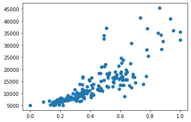

```python
plt.scatter(X[6], y)
```

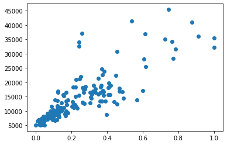

```python
plt.scatter(X[6]**2, y)
```

А для признака номер 13 линеаризовать зависимость получается с помощью функции $\frac 1 {\sqrt{\cdot}}$

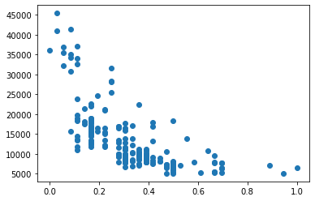

```python
plt.scatter(X[13], y)
```

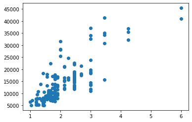

```python
plt.scatter(1/np.sqrt(X[13]), y)
```

Обратите внимание, что при генерации полиномиальных признаков матрица объекты-признаки может занимать очень много памяти. Генерация полиномиальных признаков нужна, например, в случае, если вы хотите с помощью линейной регрессии настраивать полиномиальную модель зависимости целевого признака от данных.

## Функции потерь в регрессии

Функционал качества в задачах обучения с учителем обычно задается в виде суммы по объектам выборки: $$Q(a) = \frac 1 \ell \sum_{i=1}^\ell L(y_i, a(x_i)),$$ где $L(\cdot, \cdot)$ - функция потерь, задающая штраф за разницу между предсказанием и истинным значением целевого признака. Свойства функции потерь:

- $L(y_i, a(x_i)) \geqslant 0$;
- $L(y_i, y_i) = 0$.

Функционал качества должен в первую очередь отвечать требованиям заказчика, при этом математические свойства функции потерь могут быть неудобны для оптимизации.

**Пример:** если мы не различаем маленькие ошибки (между 0.01 и 0.1 нет особой разницы), но зато не хотим получать большие ошибки, можно использовать следующую функцию потерь:

$$L(y_i, a(x_i)) = [| y_i - a(x_i) | < \varepsilon],$$

$\varepsilon$ - допустимая разница между предсказанием и фактом.

### Среднеквадратичная и средняя абсолютная ошибка

Кроме требований заказчика, функционал качества должен учитывать математические особенности модели - например, устойчивость к шумовым объектам.

В линейной регрессии Mean Squared Error: $L(y_i, a(x_i)) = (a(x_i) - y_i)^2$ не обладает этим свойством, потому что задает очень большие штрафы за большие отклонения от фактического значения.

$$MSE (a, X) = \sum^L_{i=1}(a(x_i - y_i)^2$$

Рассмотрим это явление на примере. Выберем один признак, от которого целевой признак (имеющий индекс 15 в матрице X) зависит практически линейно. Добавим к выборке два объекта-выброса и посмотрим, как изменится оптимизированная на MSE прямая.

```python
from sklearn.linear_model import LinearRegression
```

```python
X_subset = X[[7, 15]].values
X_subset_modified = np.vstack((X_subset, [[1, 90], [2, 50]])) # добавление двух шумовых точек
```

```python
def scatter_points_and_plot_line_MSE(X_subset):
    plt.scatter(X_subset[:, 0], X_subset[:, 1])   # визуализируем точки
    lr = LinearRegression()
    lr.fit(X_subset[:, 0][:, np.newaxis], X_subset[:, 1])  # найдем веса линейной модели
    grid = np.linspace(0, 2, 100)
    line = lr.predict(grid[:, np.newaxis])
    plt.plot(grid, line)   # визуализируем прямую
```

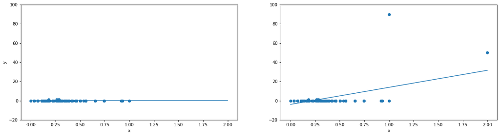

```python
plt.figure(figsize=(20, 5))
plt.subplot(1, 2, 1)
scatter_points_and_plot_line_MSE(X_subset)
plt.ylim(-20, 100)
plt.xlabel("x")
plt.ylabel("y")
plt.subplot(1, 2, 2)
scatter_points_and_plot_line_MSE(X_subset_modified)
plt.ylim(-20, 100)
plt.xlabel("x")
plt.show()
```

**Задание:** Реализуйте функцию для подсчета MSE с использованием numpy

```python
def MSE(y: np.array, y_pred: np.array):
    return np.mean((y - y_pred)**2)

a = np.array([11,20,19,17,10])
pred = np.array([12,18,19.5,18,9])
mse = MSE(y=a, y_pred=pred)
print("The Mean Square Error is: " , mse)
assert mse == 1.45
```

```
The Mean Square Error is:  1.45
```

Среднеквадратичная ошибка подходит для сравнения двух моделей или для контроля качества во время обучения, но не позволяет сделать выводы о том, насколько хорошо данная модель решает задачу. В целях сохранения размерности для интерпретации используется Root Mean Square Error (RMSE).

Отличие от MSE в данном случае лишь в том, что мы берем корень от MSE.

$$RMSE (a, X) = \sqrt{ \sum^L_{i=1}(a(x_i) - y_i)^2}$$

**Задание:** Реализуйте функцию для подсчета RMSE с использованием numpy

```python
def RMSE(y, y_pred):
    return np.sqrt(MSE(y, y_pred))


rmse = RMSE(y=a, y_pred=pred)
print("The Root Mean Square Error is: " , rmse)
assert rmse == 1.2041594578792296
```

```
The Root Mean Square Error is:  1.2041594578792296
```

Коэффициент детерминации $R^2$ используется для определения того, насколько хорошо данная модель решает задачу. $R^2$ можно интерпретировать как некоторого рода нормированное MSE.

$$R^2(a,X) = 1 - \frac {\sum^L_{i=1}(a(x_i) - y_i)^2}{\sum^L_{i=1}(y_i - \bar{y})^2}$$

**Задание:** реализуйте функцию для вычисления $R^2$

```python
def R_squared(y, y_pred):
    return 1 - MSE(y, y_pred) * len(y) / np.sum((y - np.mean(y))**2)

r_squared = R_squared(y=a, y_pred=pred)
print('The R2 is:', r_squared)
```

```
The R2 is: 0.914906103286385
```

Из-за шумовых объектов прямая достаточно сильно изменила наклон. Поэтому вместо MSE часто используют Mean Absolute Error: $L(y_i, a(x_i)) = |a(x_i) - y_i|$, который стремится уменьшать отклонение на объектах с сильной ошибкой.

$$MAE(a, X) = \frac {1}{L} \sum^L_{i=1}|a(x_i) - y_i|$$

Теперь обучим регрессию, оптимизируя MAE. В `sklearn` такая регрессия не реализована, но можно использовать модуль `statsmodels` - более формально, необходимая модель может быть получена с помощью обучения квантильной регрессии с параметром `q=0.5`.

**Задание:** Реализуйте функцию для подсчета MAE с использованием numpy

```python
def MAE(y, y_pred):
    return np.mean(np.abs(y - y_pred))


mae = MAE(y=a, y_pred=pred)
print("The Mean Absolute Error is: " , mae)
assert mae == 1.1
```

```
The Mean Absolute Error is:  1.1
```

```python
!pip install statsmodels
```

```python
import statsmodels.api as sm
import statsmodels.formula.api as smf
```

```python
def scatter_points_and_plot_line_MAE(X_subset):
    mod = smf.quantreg('f15 ~ f7', pd.DataFrame(data=X_subset, columns=["f7", "f15"])) # задаем зависимость и передаем данные
    res = mod.fit(q=0.5)
    plt.scatter(X_subset[:, 0], X_subset[:, 1])   # визуализируем точки
    grid = np.linspace(0, 2, 100)
    plt.plot(grid, grid * res.params["f7"] + res.params["Intercept"])   # визуализируем прямую
    return mod, res
```

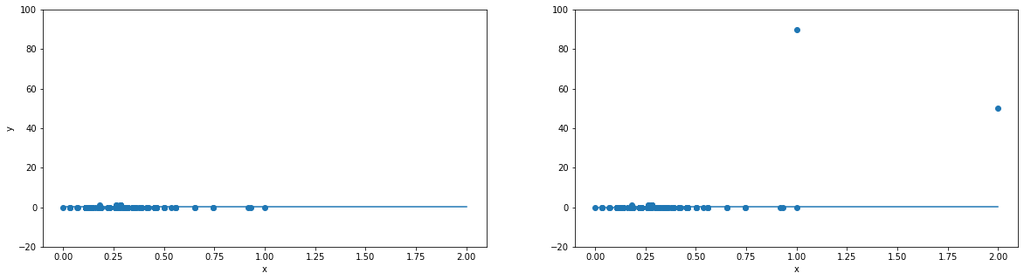

```python
plt.figure(figsize=(20, 5))
plt.subplot(1, 2, 1)
model, result = scatter_points_and_plot_line_MAE(X_subset)
plt.ylim(-20, 100)
plt.xlabel("x")
plt.ylabel("y")
plt.subplot(1, 2, 2)
model, result = scatter_points_and_plot_line_MAE(X_subset_modified)
plt.ylim(-20, 100)
plt.xlabel("x")
```

Прямая не изменила направление из-за выбросов.

Попробуем добавить больше шумовых объектов:

```python
np.random.seed(13)
X_subset_modified_twice = np.vstack((X_subset_modified, np.random.randint(5, size=60).reshape(-1, 2)*[1, 30])) # добавление 30 шумовых точек
```

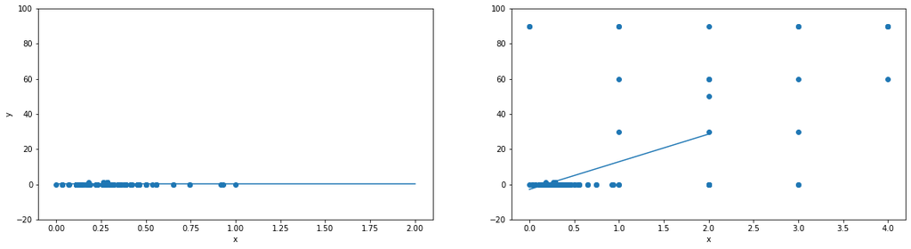

```python
plt.figure(figsize=(20, 5))
plt.subplot(1, 2, 1)
model, result = scatter_points_and_plot_line_MAE(X_subset)
plt.ylim(-20, 100)
plt.xlabel("x")
plt.ylabel("y")
plt.subplot(1, 2, 2)
model, result = scatter_points_and_plot_line_MAE(X_subset_modified_twice)
plt.ylim(-20, 100)
plt.xlabel("x")
```

Прямая изменила наклон, когда мы добавили 30 (почти 15%) шумовых точек.

### Huber Loss

Иногда используют "гибрид" MAE и MSE, который, как и MAE, устойчив к шумовым объектам, и как и MSE, мало штрафует малые отклонения от фактического значения целевого признака - Huber Loss: $$L(y_i, a(x_i)) = \phi_\varepsilon(a(x_i) - y_i)$$ $$\phi_\varepsilon(z) = \begin{cases} \frac 1 2 z^2, - \varepsilon < z < \varepsilon, \\\varepsilon (|z| - \frac 1 2 \varepsilon), иначе \\ \end{cases}$$

Легко проверить, что у этой функции существует непрерывная первая проиводная во всех точках.

Оптимизация Huber Loss реализована в sklearn:

```python
from sklearn.linear_model import HuberRegressor
```

**Задание:** реализуйте функцию потерь Хьюбера

```python
def Huber(y, y_pred):
    eps = 1e-3
    cond = np.abs(y - y_pred) - eps
    loss_vec = np.zeros(len(y))
    loss_vec[cond > 0] =  1/2 * (y[cond > 0] - y_pred[cond > 0]) ** 2
    loss_vec[cond <= 0] = eps * (np.abs(y[cond <= 0] - y_pred[cond <= 0]) - 1/2 * eps)
    return np.mean(loss_vec)

huber = Huber(y=a, y_pred=pred)
print("The Huber Loss is:", huber)
```

```
The Huber Loss is: 0.725
```

### Mean Squared Logarifmic Erorr (MSLE)

Данная функция потерь применяется в случаях, когда лучше получать заниженные прогнозы, нежели завышенные.

Важное примечание: из-за присутствия логарифма в формуле **целевая переменная должна быть неотрицательной!**

$$L(y, a) = (\log(a+1) - \log(y+1))^2$$

**Задание:** реализуйте MSLE

```python
def MSLE(y, y_pred):
    return np.mean((np.log(y_pred + 1) - np.log(y + 1))**2)

msle = MSLE(y=a, y_pred=pred)
print("The Mean Squared Logarifmic Error is:", msle)
```

```
The Mean Squared Logarifmic Error is: 0.005808110727039668
```

### Quantile Loss

В некоторых задачах штраф за ошибку зависит не только от величины абсолютного отклонения от фактического значения, но и от знака этого отклонения. Например, лучше предсказать спрос больше, чем будет по факту, чем меньше, потому что во втором случае будет потеряна прибыль. В этом случае используется квантильная регрессия со следующей функцией потерь: $$L(y_i, a(x_i)) = \rho_\tau(y_i - x_i^T w),$$ $$\rho_\tau(z) = \begin{cases} \tau z, \quad z > 0, \\ (\tau - 1) z, \quad z \leqslant 0 \end{cases}$$ Параметр $\tau \in (0, 1)$ влияет на то, насколько различаются штрафы за положительную и отрицательную разницу.

Изобразим график квантильной функции потерь вместе с некоторыми другими рассмотренными:

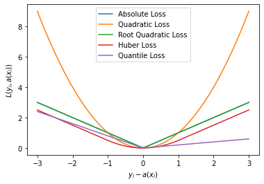

```python
grid = np.linspace(-3, 3, 100)
quantile_tau = 0.2
mse_loss = grid ** 2
rmse_loss = np.sqrt(mse_loss)
mae_loss = np.abs(grid)
huber_loss = 0.5 * mse_loss * (grid >= -1) * (grid <= 1) + (mae_loss - 0.5) * (grid < -1) + (mae_loss - 0.5)  * (grid > 1)
quantile_loss = quantile_tau * grid * (grid > 0) + (quantile_tau - 1) * grid * (grid <= 0)
plt.plot(grid, mae_loss, label="Absolute Loss")
plt.plot(grid, mse_loss, label="Quadratic Loss")
plt.plot(grid, rmse_loss, label="Root Quadratic Loss")
plt.plot(grid, huber_loss, label="Huber Loss")
plt.plot(grid, quantile_loss, label="Quantile Loss")
plt.xlabel("$y_i - a(x_i)$")
plt.ylabel("$L(y_i, a(x_i))$")
plt.legend()
```

**Задача.** Укажите параметр $\tau$, при котором обучение квантильной регрессии равносильно оптимизации MAE.

**Ответ:** 0.5

```python
from sklearn.linear_model import LinearRegression, Ridge, Lasso
from sklearn.model_selection import train_test_split, GridSearchCV
from sklearn.metrics import mean_squared_error
from sklearn.preprocessing import MinMaxScaler

import warnings

warnings.filterwarnings('ignore')
```

```python
data = pd.read_csv('crimedata.csv', na_values=["?"])
# будем работать не со всеми колонками
requiredColumns = [5, 6] + list(range(11,26)) + list(range(32, 103)) + [145]
data = data[data.columns[requiredColumns]]
# некоторые значения целевой переменной пропущены
X = data.loc[data['ViolentCrimesPerPop'].notnull(), :].drop('ViolentCrimesPerPop', axis=1)
y = data['ViolentCrimesPerPop'][X.index]
X_train, X_test, y_train, y_test = train_test_split(X, y, random_state=0)
```

Обучим линейную регрессию и выведем качество по метрике MSE на обучающей и тестовой выборке.

```python
lr = LinearRegression().fit(X_train ,y_train)
print ("Train: {}".format(mean_squared_error(y_train, lr.predict(X_train))))
print ("Test: {}".format(mean_squared_error(y_test, lr.predict(X_test))))

print ("Train: {}".format(MSE(y_train, lr.predict(X_train))))
print ("Test: {}".format(MSE(y_test, lr.predict(X_test))))
```

```
Train: 119935.90613769474
Test: 206978.8843611416
Train: 119935.90613769459
Test: 206978.88436114177
```

Популярным решением для регрессионных моделей является **регуляризация**.

Решения со сколько угодно большими весами не очень хороши, поскольку классификатор будет чувствителен к крайне маленьким изменениям в признаках объекта, а значит, переобучен.

Для решения проблемы добавим к функционалу ошибки регуляризатор, который штрафует за слишком большую норму вектора весов:

$$Q\alpha(w) = Q(w) + \alpha R(w), где$$

$R(w)$ - регуляризатор

Наиболее распространенными являются L1 и L2 регуляризаторы

$$L1: R(w) = ||w||_1 = \sum^d_i |w_i|$$$$L2: R(w) = ||w||_2 = \sum^d_i w_i^2$$

Попробуем применить каждый из них к нашей задаче.

Lasso-регрессия:

$$\|X\hat{w} - y\|^2 + \alpha\sum^d_i |w_i|$$

Ridge-регрессия:

$$\|X\hat{w} - y\|^2 + \frac{1}{2}\alpha\|w\|_2^2$$

1. В ридж-регрессии, также называемой L2-регрессией, штраф — это сумма квадратов коэффициентов переменных. В ридж-регрессии штрафы уменьшают коэффициенты при соответствующих независимых переменных, но никогда не обнуляют их. Это значит, что шумы всегда будут влиять на результат, но в очень маленькой степени.
2. Лассо или L1-регуляризация: Вместо того, чтобы начислять штрафы за каждый признак в данных, штрафы в ней начисляются лишь за признаки с большим значением коэффициентов. К тому же лассо может обнулять значения коэффициентов, тем самым полностью убирая признак из датасета (так как при вычислении результирующей переменной соответствующий признак будет умножен на ноль). Таким образом, с регрессией лассо модель может полностью избавиться от шумов в данных. В некоторых случаях это бывает очень и очень полезно!

Добавим регуляризатор и посмотрим, изменилось ли качество.

В качестве метода регуляризации используем Ridge ($L_2$-регуляризация).

```python
ridge = Ridge(5.0).fit(X_train,y_train)
print ("Train: {}".format(mean_squared_error(y_train, ridge.predict(X_train))))
print ("Test: {}".format(mean_squared_error(y_test, ridge.predict(X_test))))
```

```
Train: 120349.5502871569
Test: 206958.22395453288
```

### 2 Scaling

Попробуем MinMaxScaler.

```python
sc = MinMaxScaler()
X_train_scaled = pd.DataFrame(data=sc.fit_transform(X_train), columns=X_train.columns)
X_test_scaled = pd.DataFrame(data=sc.transform(X_test), columns=X_test.columns)
```

```python
lr = LinearRegression().fit(X_train_scaled, y_train)
mean_squared_error(y_train, lr.predict(X_train_scaled))
```

```
119949.3403021739
```

```python
mean_squared_error(y_test, lr.predict(X_test_scaled))
```

```
205682.97131382764
```

```python
lr = Ridge().fit(X_train_scaled, y_train)
mean_squared_error(y_train, lr.predict(X_train_scaled))
```

```
124690.43547001755
```

```python
mean_squared_error(y_test, lr.predict(X_test_scaled))
```

```
180421.88514772104
```

### 3 High/low variance

Полезны ли признаки, имеющие высокую дисперсию? А низкую?

```python
features_variance = X_train_scaled.var().sort_values(ascending=False)
features_variance
```

```
pctUrban               0.197731
RentHighQ              0.063005
MedYrHousBuilt         0.054831
OwnOccHiQuart          0.048807
MedRent                0.046863
                         ...
NumStreet              0.001255
NumKidsBornNeverMar    0.001249
population             0.001243
NumUnderPov            0.001160
NumImmig               0.000770
Length: 88, dtype: float64
```

Попробуем удалить признаки с самой низкой дисперсией и посмотреть, как изменится качество. В sklearn есть специальный инструмент для такого наивного отбора признаков. Стоит ли нормализовать перед этим признаки?

```python
from sklearn.feature_selection import VarianceThreshold


# можно убрать все признаки, вариативность которых меньше заданного значения
vs_transformer = VarianceThreshold(0.01)
X_train_var = pd.DataFrame(data=vs_transformer.fit_transform(X_train_scaled), columns=X_train_scaled.columns[vs_transformer.get_support()])
X_test_var = pd.DataFrame(data=vs_transformer.transform(X_test_scaled), columns=X_test_scaled.columns[vs_transformer.get_support()])

X_train_var.shape
```

```
(1495, 76)
```

```python
lr = LinearRegression().fit(X_train_var,y_train)
print ("Train: {}".format(mean_squared_error(y_train, lr.predict(X_train_var))))
print ("Test: {}".format(mean_squared_error(y_test, lr.predict(X_test_var))))
```

```
Train: 125801.65231304348
Test: 148651.77447014028
```

```python
ridge = Ridge(5.0).fit(X_train_var,y_train)
print ("Train: {}".format(mean_squared_error(y_train, ridge.predict(X_train_var))))
print ("Test: {}".format(mean_squared_error(y_test, ridge.predict(X_test_var))))
```

```
Train: 136186.7830145162
Test: 152046.21566890882
```

### 4 Correlation

Можно выбрать k признаков, которые дают наиболее высокие значения корреляции с целевой переменной.

```python
from sklearn.feature_selection import SelectKBest, f_regression


# Выбираем 15 лучших признаков
sb = SelectKBest(f_regression, k=15)

X_train_kbest = pd.DataFrame(data=sb.fit_transform(X_train_var, y_train), columns=X_train_var.columns[sb.get_support()])
X_test_kbest = pd.DataFrame(data=sb.transform(X_test_var), columns=X_test_var.columns[sb.get_support()])
```

```python
lr = LinearRegression().fit(X_train_kbest,y_train)
print ("Train: {}".format(mean_squared_error(y_train, lr.predict(X_train_kbest))))
print ("Test: {}".format(mean_squared_error(y_test, lr.predict(X_test_kbest))))
```

```
Train: 147378.18578795987
Test: 156005.78035892395
```

```python
ridge = Ridge(5.0).fit(X_train_kbest,y_train)
print ("Train: {}".format(mean_squared_error(y_train, ridge.predict(X_train_kbest))))
print ("Test: {}".format(mean_squared_error(y_test, ridge.predict(X_test_kbest))))
```

```
Train: 158023.13299833486
Test: 166680.07085931383
```

А можно выбрать самые значимые признаки с точки зрения регрессии с $L_1$-регуляризацией.

```python
from sklearn.feature_selection import SelectFromModel


lasso = Lasso(5.0)
l1_select = SelectFromModel(lasso)

X_train_l1 = pd.DataFrame(data=l1_select.fit_transform(X_train_var, y_train), columns=X_train_var.columns[l1_select.get_support()])
X_test_l1 = pd.DataFrame(data=l1_select.transform(X_test_var), columns=X_test_var.columns[l1_select.get_support()])

X_train_l1.shape
```

```
(1495, 12)
```

```python
lr = LinearRegression().fit(X_train_l1,y_train)
print ("Train: {}".format(mean_squared_error(y_train, lr.predict(X_train_l1))))
print ("Test: {}".format(mean_squared_error(y_test, lr.predict(X_test_l1))))

ridge = Ridge(5.0).fit(X_train_l1,y_train)
print ("Train: {}".format(mean_squared_error(y_train, ridge.predict(X_train_l1))))
print ("Test: {}".format(mean_squared_error(y_test, ridge.predict(X_test_l1))))
```

```
Train: 140757.45879349473
Test: 153086.92726760302
Train: 143263.16845636512
Test: 157553.36533174035
```

### 5 Pipeline

А можно сделать все вышеописанное сразу:

```python
from sklearn.pipeline import Pipeline


pipe = Pipeline(steps=[
    ('scaler', MinMaxScaler()),
    ('variance', VarianceThreshold(0.01)),
    ('selection', SelectFromModel(Lasso(5.0))),
    ('regressor', Ridge(5.0))
])

pipe.fit(X_train, y_train)

pipe.named_steps
```

```
{'scaler': MinMaxScaler(),
 'variance': VarianceThreshold(threshold=0.01),
 'selection': SelectFromModel(estimator=Lasso(alpha=5.0)),
 'regressor': Ridge(alpha=5.0)}
```

```python
print ("Train: {}".format(mean_squared_error(y_train, pipe.predict(X_train))))
print ("Test: {}".format(mean_squared_error(y_test, pipe.predict(X_test))))
```

```
Train: 143263.16845636512
Test: 157553.36533174035
```

Можно также настраивать параметры с помощью `GridSearch`:

```python
pipe.get_params()
```

```
{'memory': None,
 'regressor': Ridge(alpha=5.0, copy_X=True, fit_intercept=True, max_iter=None,
       normalize=False, random_state=None, solver='auto', tol=0.001),
 'regressor__alpha': 5.0,
 'regressor__copy_X': True,
 'regressor__fit_intercept': True,
 'regressor__max_iter': None,
 'regressor__normalize': False,
 'regressor__random_state': None,
 'regressor__solver': 'auto',
 'regressor__tol': 0.001,
 'scaler': MinMaxScaler(copy=True, feature_range=(0, 1)),
 'scaler__copy': True,
 'scaler__feature_range': (0, 1),
 'selection': SelectFromModel(estimator=Lasso(alpha=5.0, copy_X=True, fit_intercept=True,
                                 max_iter=1000, normalize=False, positive=False,
                                 precompute=False, random_state=None,
                                 selection='cyclic', tol=0.0001,
                                 warm_start=False),
                 max_features=None, norm_order=1, prefit=False, threshold=None),
 'selection__estimator': Lasso(alpha=5.0, copy_X=True, fit_intercept=True, max_iter=1000,
       normalize=False, positive=False, precompute=False, random_state=None,
       selection='cyclic', tol=0.0001, warm_start=False),
 'selection__estimator__alpha': 5.0,
 'selection__estimator__copy_X': True,
 'selection__estimator__fit_intercept': True,
 'selection__estimator__max_iter': 1000,
 'selection__estimator__normalize': False,
 'selection__estimator__positive': False,
 'selection__estimator__precompute': False,
 'selection__estimator__random_state': None,
 'selection__estimator__selection': 'cyclic',
 'selection__estimator__tol': 0.0001,
 'selection__estimator__warm_start': False,
 'selection__max_features': None,
 'selection__norm_order': 1,
 'selection__prefit': False,
 'selection__threshold': None,
 'steps': [('scaler', MinMaxScaler(copy=True, feature_range=(0, 1))),
  ('variance', VarianceThreshold(threshold=0.01)),
  ('selection',
   SelectFromModel(estimator=Lasso(alpha=5.0, copy_X=True, fit_intercept=True,
                                   max_iter=1000, normalize=False, positive=False,
                                   precompute=False, random_state=None,
                                   selection='cyclic', tol=0.0001,
                                   warm_start=False),
                   max_features=None, norm_order=1, prefit=False, threshold=None)),
  ('regressor',
   Ridge(alpha=5.0, copy_X=True, fit_intercept=True, max_iter=None,
         normalize=False, random_state=None, solver='auto', tol=0.001))],
 'variance': VarianceThreshold(threshold=0.01),
 'variance__threshold': 0.01,
 'verbose': False}
```

```python
param_grid = {
    'variance__threshold': [0.005, 0.0075, 0.009, 0.01, 0.011, 0.012],
    'selection__estimator__alpha': [0.1, 0.5, 1.0, 1.5, 2.0, 5.0, 10.0],
    'regressor__alpha': [0.1, 0.5, 1.0, 1.5, 2.0, 5.0, 10.0]
}
grid_search = GridSearchCV(pipe, param_grid, iid=False, cv=5)

grid_search.fit(X_train, y_train)
```

```
GridSearchCV(cv=5, error_score=nan,
             estimator=Pipeline(memory=None,
                                steps=[('scaler',
                                        MinMaxScaler(copy=True,
                                                     feature_range=(0, 1))),
                                       ('variance',
                                        VarianceThreshold(threshold=0.01)),
                                       ('selection',
                                        SelectFromModel(estimator=Lasso(alpha=5.0,
                                                                        copy_X=True,
                                                                        fit_intercept=True,
                                                                        max_iter=1000,
                                                                        normalize=False,
                                                                        positive=False,
                                                                        precompute=False,
                                                                        random_state=None,
                                                                        selection=...
                                              normalize=False,
                                              random_state=None, solver='auto',
                                              tol=0.001))],
                                verbose=False),
             iid=False, n_jobs=None,
             param_grid={'regressor__alpha': [0.1, 0.5, 1.0, 1.5, 2.0, 5.0,
                                              10.0],
                         'selection__estimator__alpha': [0.1, 0.5, 1.0, 1.5,
                                                         2.0, 5.0, 10.0],
                         'variance__threshold': [0.005, 0.0075, 0.009, 0.01,
                                                 0.011, 0.012]},
             pre_dispatch='2*n_jobs', refit=True, return_train_score=False,
             scoring=None, verbose=0)
```

```python
pipe_best = grid_search.best_estimator_
pipe_best.named_steps
```

```
{'regressor': Ridge(alpha=0.5, copy_X=True, fit_intercept=True, max_iter=None,
       normalize=False, random_state=None, solver='auto', tol=0.001),
 'scaler': MinMaxScaler(copy=True, feature_range=(0, 1)),
 'selection': SelectFromModel(estimator=Lasso(alpha=0.1, copy_X=True, fit_intercept=True,
                                 max_iter=1000, normalize=False, positive=False,
                                 precompute=False, random_state=None,
                                 selection='cyclic', tol=0.0001,
                                 warm_start=False),
                 max_features=None, norm_order=1, prefit=False, threshold=None),
 'variance': VarianceThreshold(threshold=0.01)}
```

```python
pipe_best.fit(X_train, y_train)
print ("Train: {}".format(mean_squared_error(y_train, pipe_best.predict(X_train))))
print ("Test: {}".format(mean_squared_error(y_test, pipe_best.predict(X_test))))
```

```
Train: 128441.16453337156
Test: 147186.92249142192
```